# Data Report: nyctaxi_cleaned

**Bottom line:** ❌ 1 critical issue(s) — fix before any analysis or modeling.

1 critical 14 warning(s) 4 note(s)

## 🚨 Findings

🚨 Class imbalance in 'store_and_fwd_flag' `store_and_fwd_flag`

Standard accuracy and many ML metrics are misleading on imbalanced data; use AUPRC, weighted loss, or resampling instead.

⚠️ 'Airport_fee' is heavily skewed (γ₁=5.10) `Airport_fee`

Mean and standard deviation are unreliable summaries here; linear models will fit poorly without a transform.

**Action:** Apply transform: yeo-johnson (right-skewed with negatives).

⚠️ 'RatecodeID' is heavily skewed (γ₁=7.07) `RatecodeID`

Mean and standard deviation are unreliable summaries here; linear models will fit poorly without a transform.

**Action:** Apply transform: log1p (right-skewed, all positive).

⚠️ 'VendorID' is heavily skewed (γ₁=4.39) `VendorID`

Mean and standard deviation are unreliable summaries here; linear models will fit poorly without a transform.

**Action:** Apply transform: log1p (right-skewed, all positive).

⚠️ 'congestion_surcharge' is heavily skewed (γ₁=-2.51) `congestion_surcharge`

Mean and standard deviation are unreliable summaries here; linear models will fit poorly without a transform.

**Action:** Apply transform: reflect+log or yeo-johnson (left-skewed).

⚠️ 'fare_amount' is heavily skewed (γ₁=3.69) `fare_amount`

Mean and standard deviation are unreliable summaries here; linear models will fit poorly without a transform.

**Action:** Apply transform: log1p (right-skewed, all positive).

⚠️ 'mta_tax' is heavily skewed (γ₁=-8.72) `mta_tax`

Mean and standard deviation are unreliable summaries here; linear models will fit poorly without a transform.

**Action:** Apply transform: reflect+log or yeo-johnson (left-skewed).

⚠️ 'passenger_count' is heavily skewed (γ₁=3.41) `passenger_count`

Mean and standard deviation are unreliable summaries here; linear models will fit poorly without a transform.

**Action:** Apply transform: log1p (right-skewed, all positive).

⚠️ 'payment_type' is heavily skewed (γ₁=3.66) `payment_type`

Mean and standard deviation are unreliable summaries here; linear models will fit poorly without a transform.

**Action:** Apply transform: log1p (right-skewed, all positive).

⚠️ 'tip_amount' is heavily skewed (γ₁=6.44) `tip_amount`

Mean and standard deviation are unreliable summaries here; linear models will fit poorly without a transform.

**Action:** Apply transform: log1p (right-skewed, all positive).

⚠️ 'tolls_amount' is heavily skewed (γ₁=33.21) `tolls_amount`

Mean and standard deviation are unreliable summaries here; linear models will fit poorly without a transform.

**Action:** Apply transform: log1p (right-skewed, all positive).

⚠️ 'fare_amount' has high VIF (767.2) `fare_amount`

Variance Inflation Factor above 10 means the column is mostly explainable from the other features; coefficient estimates in linear models will be unstable.

**Action:** Drop 'fare_amount' or merge with a correlated peer (see correlated_groups).

⚠️ 'tip_amount' has high VIF (40.1) `tip_amount`

Variance Inflation Factor above 10 means the column is mostly explainable from the other features; coefficient estimates in linear models will be unstable.

**Action:** Drop 'tip_amount' or merge with a correlated peer (see correlated_groups).

⚠️ 'tolls_amount' has high VIF (14.9) `tolls_amount`

Variance Inflation Factor above 10 means the column is mostly explainable from the other features; coefficient estimates in linear models will be unstable.

**Action:** Drop 'tolls_amount' or merge with a correlated peer (see correlated_groups).

⚠️ 'total_amount' has high VIF (1138.0) `total_amount`

Variance Inflation Factor above 10 means the column is mostly explainable from the other features; coefficient estimates in linear models will be unstable.

**Action:** Drop 'total_amount' or merge with a correlated peer (see correlated_groups).

ℹ️ 'trip_distance' and 'fare_amount' are highly correlated (r=0.915)

Strong linear relationship — likely redundant for downstream modeling, though they may capture different real-world quantities.

**Action:** Run check_multicollinearity in Phase 3 to assess VIF.

ℹ️ 'trip_distance' and 'total_amount' are highly correlated (r=0.894)

Strong linear relationship — likely redundant for downstream modeling, though they may capture different real-world quantities.

**Action:** Run check_multicollinearity in Phase 3 to assess VIF.

ℹ️ 'fare_amount' and 'total_amount' are highly correlated (r=0.973)

Strong linear relationship — likely redundant for downstream modeling, though they may capture different real-world quantities.

**Action:** Run check_multicollinearity in Phase 3 to assess VIF.

ℹ️ Correlated group of 3 features

These columns move together (|r|≥0.8) and likely measure the same underlying quantity. Keeping one is usually enough.

**Action:** Keep 'fare_amount'; drop the others.

## 🗂️ Columns

| column | kind | dtype | unique | null % | summary |
| --- | --- | --- | --- | --- | --- |
| `VendorID` | numeric | INTEGER | 3 | 0.0% | min 1 · mean 1.869 · max 7 |
| `tpep_pickup_datetime` | datetime | TIMESTAMP | 4782963 | 0.0% |  |
| `tpep_dropoff_datetime` | datetime | TIMESTAMP | 5348578 | 0.0% |  |
| `passenger_count` | numeric | BIGINT | 6 | 0.0% | min 1 · mean 1.243 · max 6 |
| `trip_distance` | numeric | DOUBLE | 4594 | 0.0% | min 0 · mean 3.417 · max 99.93 |
| `RatecodeID` | numeric | BIGINT | 6 | 4.5% | min 1 · mean 1.079 · max 6 |
| `store_and_fwd_flag` | categorical | VARCHAR | 2 | 0.0% | `N`, `Y` |
| `PULocationID` | numeric | INTEGER | 290 | 0.0% | min 1 · mean 165.2 · max 265 |
| `DOLocationID` | numeric | INTEGER | 290 | 0.0% | min 1 · mean 164.8 · max 265 |
| `payment_type` | numeric | BIGINT | 4 | 0.0% | min 1 · mean 1.145 · max 4 |
| `fare_amount` | numeric | DOUBLE | 4280 | 0.0% | min 0 · mean 19.52 · max 1000 |
| `extra` | numeric | DOUBLE | 48 | 0.0% | min 0 · mean 1.471 · max 20.71 |
| `mta_tax` | numeric | DOUBLE | 7 | 0.0% | min -0.5 · mean 0.4938 · max 4.75 |
| `tip_amount` | numeric | DOUBLE | 4577 | 0.0% | min 0 · mean 3.614 · max 766 |
| `tolls_amount` | numeric | DOUBLE | 1916 | 0.0% | min 0 · mean 0.5821 · max 1400 |
| `improvement_surcharge` | numeric | DOUBLE | 2 | 0.0% | min 0 · mean 0.9549 · max 1 |
| `total_amount` | numeric | DOUBLE | 18278 | 0.0% | min -6.75 · mean 29.04 · max 1441 |
| `congestion_surcharge` | numeric | DOUBLE | 4 | 0.0% | min -2.5 · mean 2.225 · max 2.5 |
| `Airport_fee` | numeric | DOUBLE | 13 | 0.0% | min -2 · mean 0.1553 · max 27 |
| `cbd_congestion_fee` | numeric | DOUBLE | 3 | 0.0% | min -0.75 · mean 0.5293 · max 0.75 |

## 🔬 Per-column deep dive

### `VendorID` numeric

INTEGER · 3 unique (0.0%) · 0.0% null

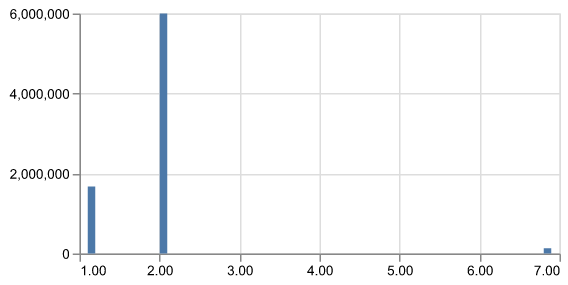

**min**

1

**p25**

2

**median**

2

**mean**

1.869

**p75**

2

**max**

7

**std**

0.7858

**skew**

4.388

**kurt**

27.85

⚠️ 'VendorID' is heavily skewed (γ₁=4.39)

### `tpep_pickup_datetime` datetime

TIMESTAMP · 4,782,963 unique (61.3%) · 0.0% null

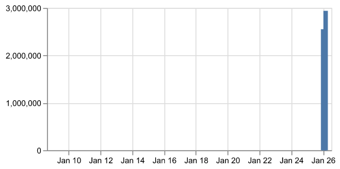

**min**

2008-12-31 23:03:20

**max**

2026-04-01 00:06:25

### `tpep_dropoff_datetime` datetime

TIMESTAMP · 5,348,578 unique (68.5%) · 0.0% null

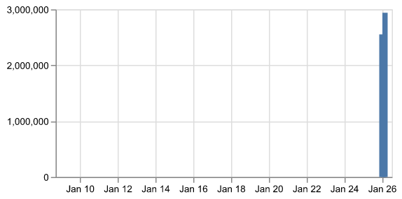

**min**

2009-01-01 00:07:36

**max**

2026-04-01 21:11:01

### `passenger_count` numeric

BIGINT · 6 unique (0.0%) · 0.0% null

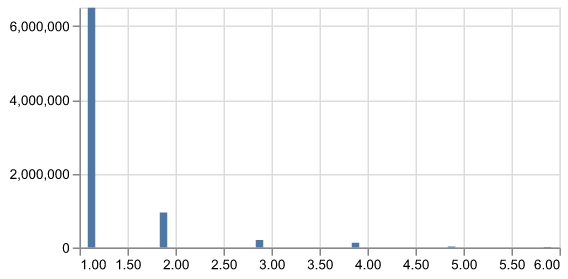

**min**

1

**p25**

1

**median**

1

**mean**

1.243

**p75**

1

**max**

6

**std**

0.638

**skew**

3.407

**kurt**

13.86

⚠️ 'passenger_count' is heavily skewed (γ₁=3.41)

### `trip_distance` numeric

DOUBLE · 4,594 unique (0.1%) · 0.0% null

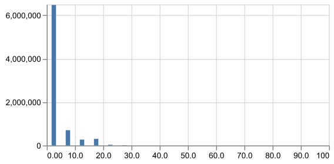

**min**

0

**p25**

0.99

**median**

1.679

**mean**

3.417

**p75**

3.33

**max**

99.93

**std**

4.558

**skew**

2.927

**kurt**

12.69

### `RatecodeID` numeric

BIGINT · 6 unique (0.0%) · 4.5% null

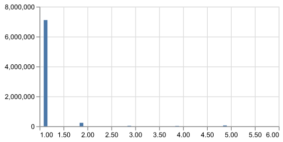

**min**

1

**p25**

1

**median**

1

**mean**

1.079

**p75**

1

**max**

6

**std**

0.4349

**skew**

7.073

**kurt**

55.04

⚠️ 'RatecodeID' is heavily skewed (γ₁=7.07)

### `store_and_fwd_flag` categorical

VARCHAR · 2 unique (0.0%) · 0.0% null

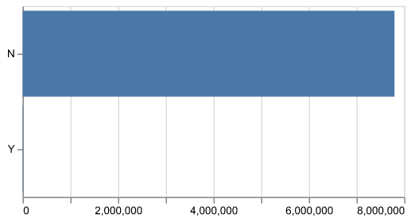

**`N`**

7796040

**`Y`**

8483

🚨 Class imbalance in 'store_and_fwd_flag'

### `PULocationID` numeric

INTEGER · 290 unique (0.0%) · 0.0% null

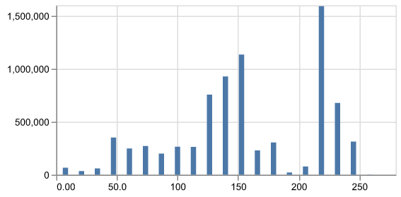

**min**

1

**p25**

132

**median**

162

**mean**

165.2

**p75**

234

**max**

265

**std**

63.65

**skew**

-0.272

**kurt**

-0.8216

### `DOLocationID` numeric

INTEGER · 290 unique (0.0%) · 0.0% null

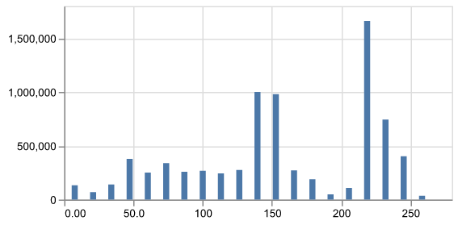

**min**

1

**p25**

115

**median**

162

**mean**

164.8

**p75**

235

**max**

265

**std**

69.6

**skew**

-0.3717

**kurt**

-0.9356

### `payment_type` numeric

BIGINT · 4 unique (0.0%) · 0.0% null

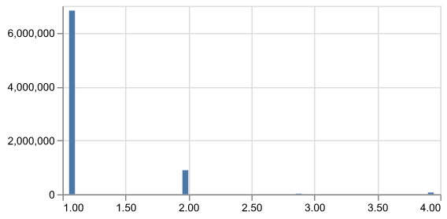

**min**

1

**p25**

1

**median**

1

**mean**

1.145

**p75**

1

**max**

4

**std**

0.4229

**skew**

3.661

**kurt**

16.87

⚠️ 'payment_type' is heavily skewed (γ₁=3.66)

### `fare_amount` numeric

DOUBLE · 4,280 unique (0.1%) · 0.0% null

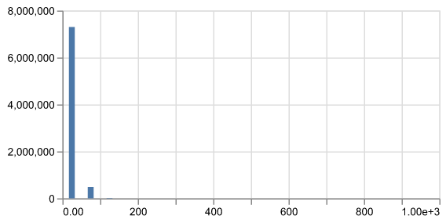

**min**

0

**p25**

9.186

**median**

13.49

**mean**

19.52

**p75**

22.12

**max**

1e+03

**std**

18.02

**skew**

3.691

**kurt**

39.01

⚠️ 'fare_amount' is heavily skewed (γ₁=3.69)

⚠️ 'fare_amount' has high VIF (767.2)

### `extra` numeric

DOUBLE · 48 unique (0.0%) · 0.0% null

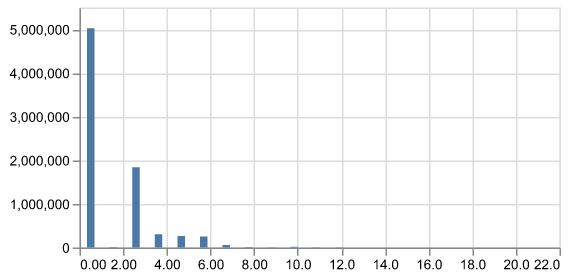

**min**

0

**p25**

0

**median**

1

**mean**

1.471

**p75**

2.5

**max**

20.71

**std**

1.85

**skew**

1.496

**kurt**

2.623

### `mta_tax` numeric

DOUBLE · 7 unique (0.0%) · 0.0% null

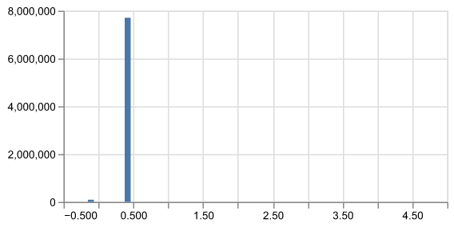

**min**

-0.5

**p25**

0.5

**median**

0.5

**mean**

0.4938

**p75**

0.5

**max**

4.75

**std**

0.05609

**skew**

-8.717

**kurt**

102.8

⚠️ 'mta_tax' is heavily skewed (γ₁=-8.72)

### `tip_amount` numeric

DOUBLE · 4,577 unique (0.1%) · 0.0% null

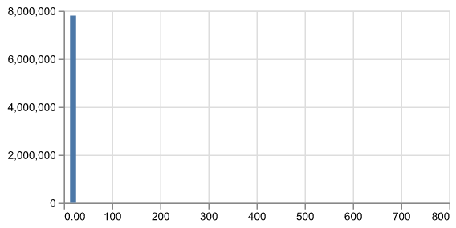

**min**

0

**p25**

1.089

**median**

2.949

**mean**

3.614

**p75**

4.465

**max**

766

**std**

4.036

**skew**

6.44

**kurt**

492.7

⚠️ 'tip_amount' is heavily skewed (γ₁=6.44)

⚠️ 'tip_amount' has high VIF (40.1)

### `tolls_amount` numeric

DOUBLE · 1,916 unique (0.0%) · 0.0% null

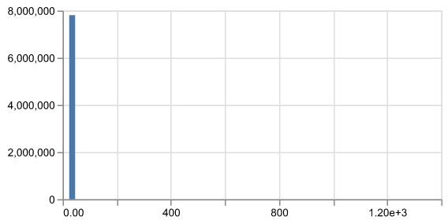

**min**

0

**p25**

0

**median**

0

**mean**

0.5821

**p75**

0

**max**

1.4e+03

**std**

2.321

**skew**

33.21

**kurt**

1.7e+04

⚠️ 'tolls_amount' is heavily skewed (γ₁=33.21)

⚠️ 'tolls_amount' has high VIF (14.9)

### `improvement_surcharge` numeric

DOUBLE · 2 unique (0.0%) · 0.0% null

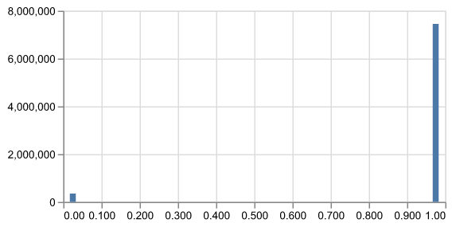

**min**

0

**p25**

1

**median**

1

**mean**

0.9549

**p75**

1

**max**

1

**std**

0.2076

**skew**

-4.382

**kurt**

17.2

### `total_amount` numeric

DOUBLE · 18,278 unique (0.2%) · 0.0% null

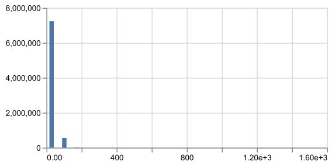

**min**

-6.75

**p25**

16.52

**median**

21.62

**mean**

29.04

**p75**

31.22

**max**

1.44e+03

**std**

22.44

**skew**

3.39

**kurt**

27.45

⚠️ 'total_amount' has high VIF (1138.0)

### `congestion_surcharge` numeric

DOUBLE · 4 unique (0.0%) · 0.0% null

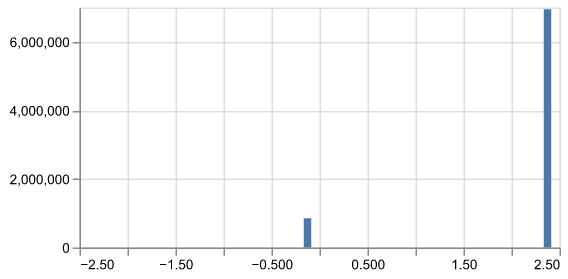

**min**

-2.5

**p25**

2.5

**median**

2.5

**mean**

2.225

**p75**

2.5

**max**

2.5

**std**

0.7835

**skew**

-2.512

**kurt**

4.388

⚠️ 'congestion_surcharge' is heavily skewed (γ₁=-2.51)

### `Airport_fee` numeric

DOUBLE · 13 unique (0.0%) · 0.0% null

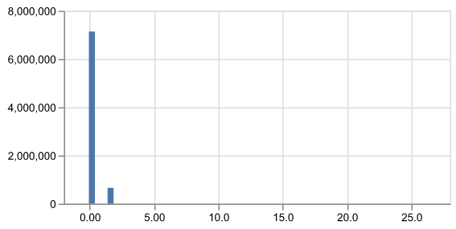

**min**

-2

**p25**

0

**median**

0

**mean**

0.1553

**p75**

0

**max**

27

**std**

0.5328

**skew**

5.104

**kurt**

83.9

⚠️ 'Airport_fee' is heavily skewed (γ₁=5.10)

### `cbd_congestion_fee` numeric

DOUBLE · 3 unique (0.0%) · 0.0% null

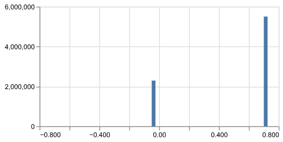

**min**

-0.75

**p25**

0

**median**

0.75

**mean**

0.5293

**p75**

0.75

**max**

0.75

**std**

0.342

**skew**

-0.9076

**kurt**

-1.163

## 🔎 Sample (first 10 rows)

| VendorID | tpep_pickup_datetime | tpep_dropoff_datetime | passenger_count | trip_distance | RatecodeID | store_and_fwd_flag | PULocationID | DOLocationID | payment_type | fare_amount | extra | mta_tax | tip_amount | tolls_amount | improvement_surcharge | total_amount | congestion_surcharge | Airport_fee | cbd_congestion_fee |
| --- | --- | --- | --- | --- | --- | --- | --- | --- | --- | --- | --- | --- | --- | --- | --- | --- | --- | --- | --- |
| 2 | 2026-01-01 00:54:04 | 2026-01-01 00:59:37 | 1 | 0.97 | 1 | N | 239 | 238 | 1 | 7.2 | 1.0 | 0.5 | 3.66 | 0.0 | 1.0 | 15.86 | 2.5 | 0.0 | 0.0 |
| 2 | 2026-01-01 00:15:22 | 2026-01-01 00:58:10 | 4 | 5.58 | 1 | N | 142 | 209 | 1 | 38.7 | 1.0 | 0.5 | 11.11 | 0.0 | 1.0 | 55.56 | 2.5 | 0.0 | 0.75 |
| 2 | 2026-01-01 00:47:11 | 2026-01-01 01:00:47 | 2 | 2.33 | 1 | N | 144 | 137 | 1 | 14.2 | 1.0 | 0.5 | 4.99 | 0.0 | 1.0 | 24.94 | 2.5 | 0.0 | 0.75 |
| 1 | 2026-01-01 00:17:54 | 2026-01-01 00:28:32 | 1 | 1.3 | 1 | N | 142 | 50 | 2 | 11.4 | 4.25 | 0.5 | 0.0 | 0.0 | 1.0 | 17.15 | 2.5 | 0.0 | 0.75 |
| 2 | 2026-01-01 00:34:14 | 2026-01-01 01:11:58 | 1 | 5.34 | 1 | N | 161 | 45 | 1 | 37.3 | 1.0 | 0.5 | 8.61 | 0.0 | 1.0 | 51.66 | 2.5 | 0.0 | 0.75 |
| 2 | 2026-01-01 00:41:07 | 2026-01-01 00:50:42 | 3 | 1.83 | 1 | N | 237 | 263 | 1 | 10.7 | 1.0 | 0.5 | 2.36 | 0.0 | 1.0 | 18.06 | 2.5 | 0.0 | 0.0 |
| 2 | 2026-01-01 00:12:46 | 2026-01-01 00:48:58 | 1 | 3.09 | 1 | N | 161 | 144 | 1 | 29.6 | 1.0 | 0.5 | 7.07 | 0.0 | 1.0 | 42.42 | 2.5 | 0.0 | 0.75 |
| 2 | 2026-01-01 00:50:40 | 2026-01-01 01:03:09 | 1 | 1.26 | 1 | N | 144 | 79 | 1 | 12.1 | 1.0 | 0.5 | 3.57 | 0.0 | 1.0 | 21.42 | 2.5 | 0.0 | 0.75 |
| 1 | 2026-01-01 00:21:33 | 2026-01-01 00:49:14 | 2 | 0.9 | 1 | N | 163 | 48 | 2 | 21.9 | 4.25 | 0.5 | 0.0 | 0.0 | 1.0 | 27.65 | 2.5 | 0.0 | 0.75 |
| 2 | 2026-01-01 00:42:31 | 2026-01-01 00:44:28 | 3 | 0.33 | 1 | N | 234 | 90 | 2 | 4.4 | 1.0 | 0.5 | 0.0 | 0.0 | 1.0 | 10.15 | 2.5 | 0.0 | 0.75 |

Generated by edamcp · run_id `eda_nyctaxi_cleaned_20260610_203045_af2107` · 2026-06-10 20:30:59